# Doğrusal Modelleme Uygulaması - 1

Emrah Kırdök, Ph. D.

3/10/2022

# 1 Doğrusal modelleme, Doğrusal regresyon

## 1.1 Kütüphanler

Bu kısım kapsamında kullanılacak veri setlerinin ve fonksiyonlar için iki farklı kütüphane gereklidir:

- `MASS` (R içerisinde gelmektedir)
- `ISLR2` (Bu kütüphanenin yüklenmesi gerekidir)

Eğer daha önce `ISLR2` paketini yüklemediyseniz, öncelikle aşağıdaki gibi bu paketi yüklemelisiniz:

```r
install.packages("ISLR2")
```

Daha sonra bu paketleri çalışma ortamımıza yükleyelim:

```r
library("MASS")
library("ISLR2")
```

## 1.2 Basit doğrusal regresyon

```r
head(Boston)
```

```
##      crim zn indus chas   nox    rm  age    dis rad tax ptratio lstat medv
## 1 0.00632 18  2.31    0 0.538 6.575 65.2 4.0900   1 296    15.3  4.98 24.0
## 2 0.02731  0  7.07    0 0.469 6.421 78.9 4.9671   2 242    17.8  9.14 21.6
## 3 0.02729  0  7.07    0 0.469 7.185 61.1 4.9671   2 242    17.8  4.03 34.7
## 4 0.03237  0  2.18    0 0.458 6.998 45.8 6.0622   3 222    18.7  2.94 33.4
## 5 0.06905  0  2.18    0 0.458 7.147 54.2 6.0622   3 222    18.7  5.33 36.2
## 6 0.02985  0  2.18    0 0.458 6.430 58.7 6.0622   3 222    18.7  5.21 28.7
```

Bu veriseti Boston’un 506 farklı bölgesindeki evlerin fiyatlarını göstermektedir. Şimdi kullanacağımız sütun isimlerine bakalım:

- `medv`: ortanca ev fiyatı, her bölgedeki ortanca ev fiyatını belirtmektedir
- `lstat`: her bölgede bulunan sosyoekonomik açıdan düşük gelir seviyesine sahip ev sayısı

Bu veri seti hakkında daha fazla bilgi almak için [bu bağlantıya tıklayınız](https://www.cs.toronto.edu/~delve/data/boston/bostonDetail.html).

Bu çalışma kapsamında, `medv` ve `lstat` değişkenleri arasındaki ilişkiyi, doğrusal regresyon ile modellemeye çalışacağız. Acaba bir mahallenin sosyoekonomik statüsü, mahalledeki evlerin fiyatını etkiliyor mu?

Öncelikle bu iki değişken arasındaki ilişkiyi görselleştirelim. Bunun için basitçe bir grafik kullanabiliriz (Şekil 1.1):

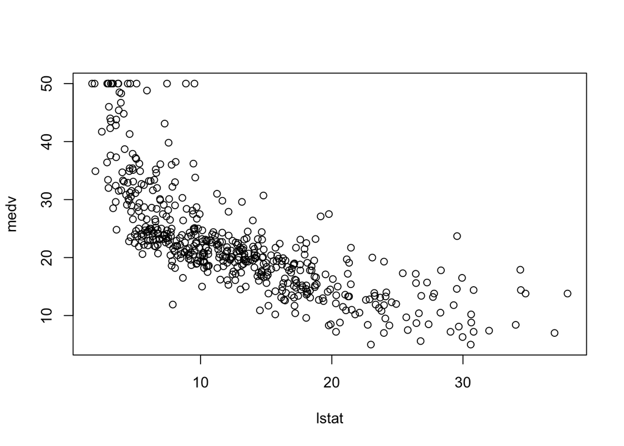

Figure 1.1: Boston veri setinde bulunan `medv` ve `lstat` değişkenleri arasındaki ilişki

```r
plot(medv~lstat, data = Boston)
```

R üzerinde herşeyin birden çok çözüm yolu bulunmaktadır. Mesela bu grafiği oluşturmak için üç farklı yol kullanabiliriz:

```r
plot(medv~lstat, data = Boston)
plot(Boston$medv~Boston$lstat)

attach(Boston)
plot(medv~lstat)
```

Burada kullandığımız `attach` foknsiyonu, bahsi geçen veri setinde bulunan sütunları doğrudan kullanmamızı sağlar. Dolayısıyla, veri setini bir kere `attach` foksiyonu ile bağladık mı, sütun isimlerini doğrudan kullabiliriz.

Ancak, kodlarımızın daha açık ve okunabilir olması açısından ben aşağıdaki tarzı tercih edeceğim:

```r
plot(medv~lstat, data = Boston)
```

Sizce bu şekil ne anlatıyor? Sosyoekonomik seviye düşüşü, ev fiyatlarını sizce nasıl etkiliyor olabilir? Bu noktada bir durup düşünün.

Peki, bu iki değişken arasındaki ilişkiyi doğrusal regresyon ile nasıl modelleyebilriz?

```r
lm.fit <- lm(medv ~ lstat, data = Boston)
```

Modelin sahip olduğu bilgileri almak için `summary` fonksiyonunu kullanabiliriz. Bu sayede $p$-değerlerini inceleyebiliriz:

```r
summary(lm.fit)
```

```
##
## Call:
## lm(formula = medv ~ lstat, data = Boston)
##
## Residuals:
##     Min      1Q  Median      3Q     Max
## -15.168  -3.990  -1.318   2.034  24.500
##
## Coefficients:
##             Estimate Std. Error t value Pr(>|t|)
## (Intercept) 34.55384    0.56263   61.41   <2e-16 ***
## lstat       -0.95005    0.03873  -24.53   <2e-16 ***
## ---
## Signif. codes:  0 '***' 0.001 '**' 0.01 '*' 0.05 '.' 0.1 ' ' 1
##
## Residual standard error: 6.216 on 504 degrees of freedom
## Multiple R-squared:  0.5441, Adjusted R-squared:  0.5432
## F-statistic: 601.6 on 1 and 504 DF,  p-value: < 2.2e-16
```

Modeldeki isimleri elde etmek için

```r
names(lm.fit)
```

```
##  [1] "coefficients"  "residuals"     "effects"       "rank"
##  [5] "fitted.values" "assign"        "qr"            "df.residual"
##  [9] "xlevels"       "call"          "terms"         "model"
```

Modeldeki katsayıları elde etmek için `coef` fonksiyonunu kullabiliriz:

```r
coef(lm.fit)
```

```
## (Intercept)       lstat
##  34.5538409  -0.9500494
```

Elde ettiğimiz katsayılar aslında derslerde gördüğümüz $\beta_{0}$ ve $\beta_{1}$ parametrelerini ifade etmektedir.

Güven aralıklarını (%95) elde etmek için ise `confint` fonkisyonunu kullanabiliriz:

```r
confint(lm.fit)
```

```
##                 2.5 %     97.5 %
## (Intercept) 33.448457 35.6592247
## lstat       -1.026148 -0.8739505
```

Eğer Şekil 1.1’i dikkatle incelerseniz, iki değişken arasında doğrusal olmayan bir ilişki görebilme imkanınız var. Derslerde de belirttiğimiz gibi, aslında mükemmel bir doğrusal ilişki bulma imkanınız yok. Bizim burada yaptığımız ise, aslında iki değişken arasındaki ilişkiyi en iyi ifade eden doğrusal modeli elde etmek.

Bunu daha iyi olarak, doğrusal modeli çizerek gösterebiliriz (Şekil 1.2).

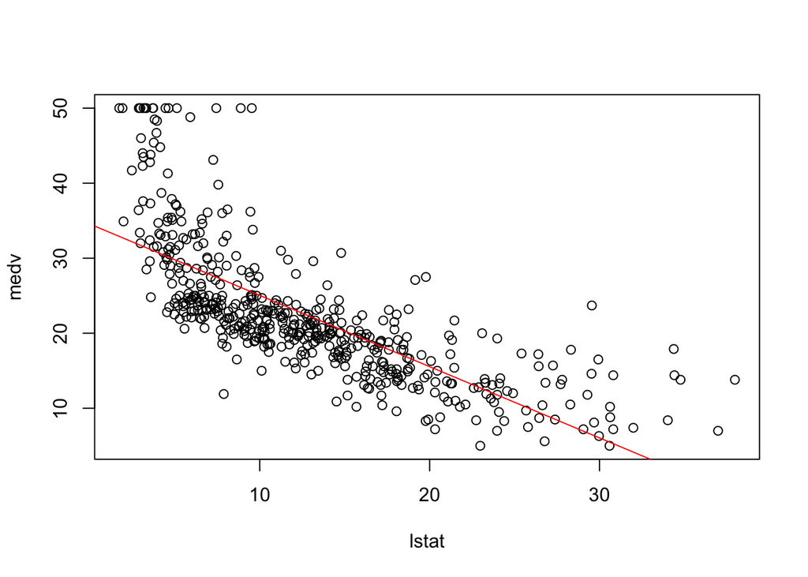

Figure 1.2: Boston veri setinden oluştruğdumuz doğrusal modelin grafik üzerinde gösterilmesi

```r
plot(medv~lstat, data=Boston)
abline(lm.fit, col = "red")
```

Son olarak, R bize farklı grafikler ile, oluşturduğumuz model hakkında daha fazla bilgi vermektedir (Şekil 1.3). Burada dikkat etmemiz gereken grafik, sol üstteki *Residuals cs Fitted* grafiği. Derste, artıklardan bahsetmiştik. Bu artık değerlerinin homojen bir şekilde doğrusal modelin etrafında dağıması ideal olacaktır. Aslında x eksenindeki girdi ile, artıklar arasında hiç bir ilişkinin olmaması gerekir.

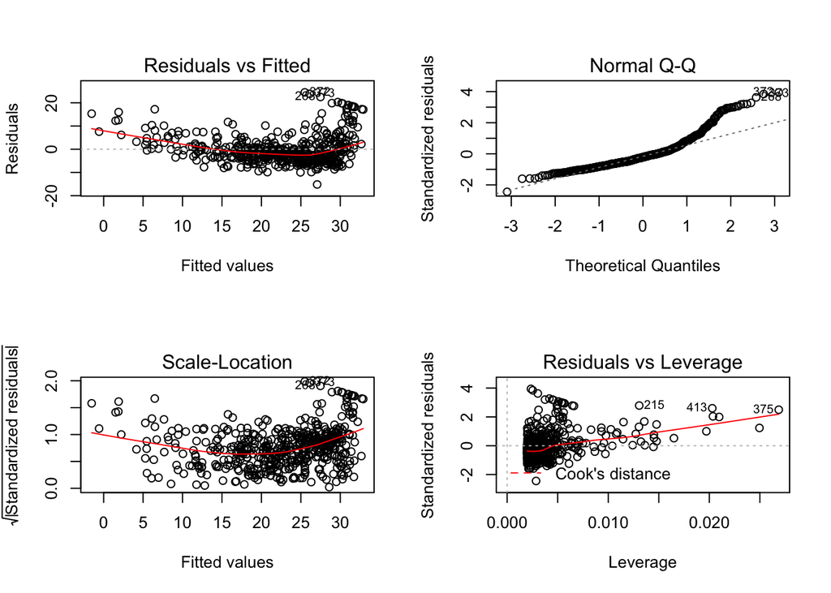

Figure 1.3: R içerisinde gelen doğrusal modelleme fonksiyonundaki çıktılar. Burada en önemlisi bizim sol üstteki grafiğimiz. Burada artık değerleri ile $x$ ekseni arasındaki ilişki irdeleniyor. Artıkların, x ekseni ile az da olsa bir ilişkisi var

```r
opar <- par(no.readonly = TRUE)  # copy of current settings
par(mfrow = c(2, 2))             # 2 * 2
plot(lm.fit)
```

İdeal olarak baktığımızda, artık değerlerinin aslında çizdiğimiz doğrusal model etrafında homojen bir şekilde dağılmasını bekleriz. Bu bize aslında artık değerleriyle, $x$ eksenindeki değişken arasında bir ilişki olmamasını beraberinde getirir.

Ancak grafiğe baktığımızda, artıklar ile x arasında az da olsa bir ilişki var. Bu çok istenen bir durum değildir. Benim bu noktadaki yorumum şu olur:

> Elimizdeki değişkenler arasında doğrusal bir ilişki olmadığı için, artıklar doğrusal model etrafında homojen bir şekilde dağılmamıştır.

## 1.3 Ekstralar: `ggplot` ile denemeler

Eğer buraya kadar geldiyseniz, `ggplot2`’yi mutlaka denemelisiniz. Şimdi aynı grafikleri ggplot2 ile tekrarlayalım (Şekil 1.4). R üzerinde harka görselleştirme araçları mevcuttur. Bununla ilgili görselleştirmeleri internet sitesinde paylaştım.

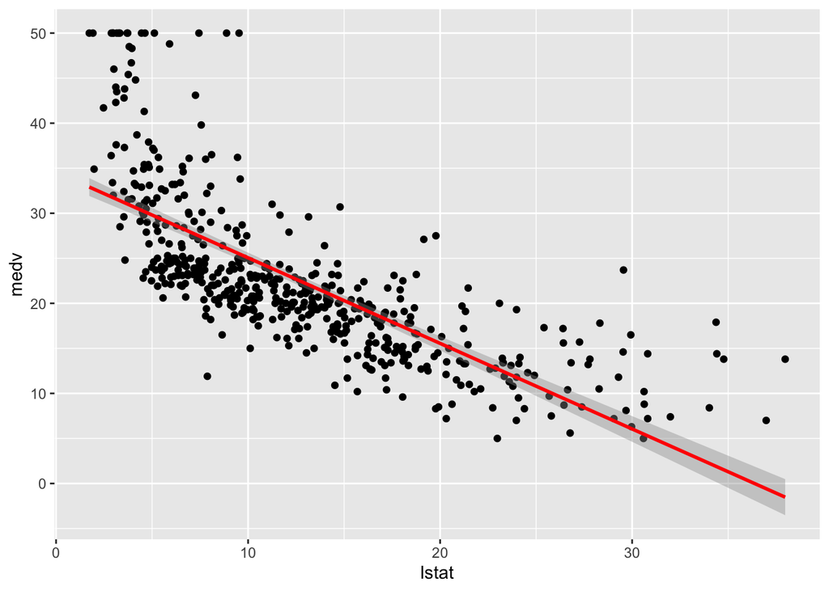

Figure 1.4: ggplot2 ile oluşturulmuş bir grafik

```r
library(ggplot2)
ggplot(data = Boston, aes(x = lstat, y = medv)) +
  geom_point() +
  geom_smooth(method = "lm", color = "red")
```